# Practice Activity 4: Tidy Data with tidyr

- Show All Code
- Hide All Code
- View Source

Author

Matthew Chen

Today you will be tidying untidy data to explore the relationship between countries of the world and military spending.

## Data for Today’s Activity

The SIPRI (Stockholm International Peace Research Institute) Military Expenditure Database is an open source dataset with contains consistent time series on the military spending of countries for the period 1949–2018. The database is updated annually, which may include updates to data for any of the years included in the database.

Military expenditure in local currency at current prices is presented according to both the financial year of each country and according to calendar year, calculated on the assumption that, where financial years do not correspond to calendar years, spending is distributed evenly through the year. Figures in constant (2017) and current US $, as a share of GDP and per capita are presented according to calendar year. The availability of data varies considerably by country, but for a majority of countries that were independent at the time, data is available from at least the late 1950s. Estimates for regional military expenditure have been extended backwards depending on availability of data for countries in the region, but no estimates for total world military expenditure are available before 1988 due to the lack of data for the Soviet Union.

SIPRI military expenditure data is based on open sources only.

## Data Inspection

1. Download the `gov_spending_per_capita.xlsx` data.
2. Open the Excel file and inspect the file.

First, you should notice that there are ten different sheets included in the dataset. We are interested in the sheet labeled “Share of Govt. spending” which contains information about the share of government spending that is allocated to military spending.

Next, you’ll notice that there are notes about the dataset in the first six rows. Ugh! Also notice that the last six rows are footnotes about the dataset. **Ugh**!

Rather than copying this one sheet into a new Excel file and deleting the first and last six rows, let’s learn something new about the `read_xlsx()` function!

## Data Import

The `read_xlsx()` function has a `sheet` argument, where you specify the name of the sheet that you want to use.

The `read_xlsx()` function also has a `skip` argument, where you specify the number of rows you want to be skipped *before* reading in the data.

Finally, `read_xlsx()` also has a `n_max` argument, where you specify the maximum number of rows of data to read in.

**1. Modify the code below to read the military expenditures data into your work space.**

```r
library(readxl)
library(tidyverse)
library(dplyr)
library(here)

military <- read_xlsx(here::here("week 4",
                                 "gov_spending_per_capita.xlsx"),
                      sheet = "Share of Govt. spending",
                      skip = 6,
                      n_max = 191)
```

## Data Cleaning

### Missing Values

In addition to `NA`s, missing or unavailable values were coded two ways.

**2. Find these two methods and write the code to replace these values with NAs. Save the mutated dataset into a new object named `military_clean`.**

```r
military_clean <- military %>%
  mutate(across(.cols = `1988`:`2019`,
                .fns = ~ na_if(.x , y = ". .")
                ),
         across(.cols = `1988`:`2019`,
                .fns = ~ na_if(.x, y = "xxx")
                )
         )
```

Because of the use of characters to mark missing values, all of the columns 1988 through 2019 were read in a characters.

**3. Mutate these columns to all be numeric data types, instead of a character data type. Save these changes into an updated version of `military_clean`.**

```r
military_clean <- military_clean %>%
  mutate(across(.cols = `1988`:`2019`,
                .fns = as.numeric)
         )
```

### Incorrect Regions

If you give the `Country` column a look, you’ll see that there are names of continents **and** regions included. These names are only included to make it simpler to find countries, as they contain no data.

Luckily for us, these region names were also stored in the “Regional totals” sheet. We can us the `Region` column of this dataset to filter out the names we don’t want.

Run the code below to read in the “Regional totals” dataset, making any necessary modifications to the path.

```r
cont_region <- read_xlsx(here::here("week 4",
                                    "gov_spending_per_capita.xlsx"),
                      sheet = "Regional totals",
                      skip = 14) |>
  filter(Region != "World total (including Iraq)",
         Region != "World total (excluding Iraq)")
```

If you think about `filter()`ing data, so that only certain values of a variable are retained, we should remember our friendly `%in%` function! However, if you think about the code below, you should notice that this code retains only the values we wanted to remove!

```r
military_clean |>
  filter(Country %in% cont_region$Region)
```

```
# A tibble: 14 × 35
   Country Notes Repor…¹ `1988` `1989` `1990` `1991` `1992` `1993` `1994` `1995`
   <chr>   <chr> <chr>    <dbl>  <dbl>  <dbl>  <dbl>  <dbl>  <dbl>  <dbl>  <dbl>
 1 Africa  <NA>  <NA>        NA     NA     NA     NA     NA     NA     NA     NA
 2 North … <NA>  <NA>        NA     NA     NA     NA     NA     NA     NA     NA
 3 Americ… <NA>  <NA>        NA     NA     NA     NA     NA     NA     NA     NA
 4 North … <NA>  <NA>        NA     NA     NA     NA     NA     NA     NA     NA
 5 South … <NA>  <NA>        NA     NA     NA     NA     NA     NA     NA     NA
 6 Centra… <NA>  <NA>        NA     NA     NA     NA     NA     NA     NA     NA
 7 East A… <NA>  <NA>        NA     NA     NA     NA     NA     NA     NA     NA
 8 South … <NA>  <NA>        NA     NA     NA     NA     NA     NA     NA     NA
 9 South-… <NA>  <NA>        NA     NA     NA     NA     NA     NA     NA     NA
10 Oceania <NA>  <NA>        NA     NA     NA     NA     NA     NA     NA     NA
11 Europe  <NA>  <NA>        NA     NA     NA     NA     NA     NA     NA     NA
12 Centra… <NA>  <NA>        NA     NA     NA     NA     NA     NA     NA     NA
13 Easter… <NA>  <NA>        NA     NA     NA     NA     NA     NA     NA     NA
14 Wester… <NA>  <NA>        NA     NA     NA     NA     NA     NA     NA     NA
# … with 24 more variables: `1996` <dbl>, `1997` <dbl>, `1998` <dbl>,
#   `1999` <dbl>, `2000` <dbl>, `2001` <dbl>, `2002` <dbl>, `2003` <dbl>,
#   `2004` <dbl>, `2005` <dbl>, `2006` <dbl>, `2007` <dbl>, `2008` <dbl>,
#   `2009` <dbl>, `2010` <dbl>, `2011` <dbl>, `2012` <dbl>, `2013` <dbl>,
#   `2014` <dbl>, `2015` <dbl>, `2016` <dbl>, `2017` <dbl>, `2018` <dbl>,
#   `2019` <dbl>, and abbreviated variable name ¹`Reporting year`
```

Unfortunately, R doesn’t come with a built-in `!%in%` function. However, a clever way to filter out observations you don’t want is with a join. A tool tailored just for this scenario is the `anti_join()` function. This function will return all of the rows of one dataset **without** a match in another dataset.

**4. Use the `anti_join()` function to filter out the `Country` values we don’t want in the `military_clean` dataset. The `by` argument needs to be filled with the name(s) of the variables that the two datasets should be joined with.**

**Tip**

To join by different variables on `x` and `y`, use a named vector. For example, `by = c("a" = "b")` will match `x$a` to `y$b`.

```r
 military_clean<-anti_join(military_clean,cont_region,by =
                             c("Country" = "Region"))
```

## Part One Answer

What regions were not removed from the `military_clean` dataset? Use their correct capitalization **and** punctuation!

**Tip**

Looking at the dataset, you should notice that the continents included in the `Country` column have missing values for the `1988` to `2019` columns. Use this information to locate what continents still remain!

**Danger**

Using `across()` in `filter()` was deprecated in dplyr 1.0.8. It is advised to use `if_any()` or `if_all()` instead. For help on these functions, pull up their help file!

```r
military_clean|>
  filter(if_all(`1988`:`2019`,is.na))
```

```
# A tibble: 12 × 35
   Country Notes Repor…¹ `1988` `1989` `1990` `1991` `1992` `1993` `1994` `1995`
   <chr>   <chr> <chr>    <dbl>  <dbl>  <dbl>  <dbl>  <dbl>  <dbl>  <dbl>  <dbl>
 1 Sub-Sa… <NA>  <NA>        NA     NA     NA     NA     NA     NA     NA     NA
 2 Somalia 22    <NA>        NA     NA     NA     NA     NA     NA     NA     NA
 3 Centra… <NA>  <NA>        NA     NA     NA     NA     NA     NA     NA     NA
 4 Cuba    29    <NA>        NA     NA     NA     NA     NA     NA     NA     NA
 5 Venezu… 44    <NA>        NA     NA     NA     NA     NA     NA     NA     NA
 6 Asia &… <NA>  <NA>        NA     NA     NA     NA     NA     NA     NA     NA
 7 Korea,… 51    <NA>        NA     NA     NA     NA     NA     NA     NA     NA
 8 Czecho… 70    <NA>        NA     NA     NA     NA     NA     NA     NA     NA
 9 German… 71    <NA>        NA     NA     NA     NA     NA     NA     NA     NA
10 Yugosl… 76    <NA>        NA     NA     NA     NA     NA     NA     NA     NA
11 Middle… <NA>  <NA>        NA     NA     NA     NA     NA     NA     NA     NA
12 Yemen,… 103   <NA>        NA     NA     NA     NA     NA     NA     NA     NA
# … with 24 more variables: `1996` <dbl>, `1997` <dbl>, `1998` <dbl>,
#   `1999` <dbl>, `2000` <dbl>, `2001` <dbl>, `2002` <dbl>, `2003` <dbl>,
#   `2004` <dbl>, `2005` <dbl>, `2006` <dbl>, `2007` <dbl>, `2008` <dbl>,
#   `2009` <dbl>, `2010` <dbl>, `2011` <dbl>, `2012` <dbl>, `2013` <dbl>,
#   `2014` <dbl>, `2015` <dbl>, `2016` <dbl>, `2017` <dbl>, `2018` <dbl>,
#   `2019` <dbl>, and abbreviated variable name ¹`Reporting year`
```

## Data Organization

The comparison I am interested in looking at the military expenditures across every year in the data. Something like this:

[figure not shown]

Unfortunately, this requires that every year is included in one column!

Each of these pieces form the three required arguments to the `pivot_longer()` function.

**4. Pivot the cleaned up `military` dataset to a “longer” orientation. Save this new “long” version as a new dataset.**

**Danger**

**Do not** overwrite your cleaned up dataset! Save your longer data as a new object!

```r
military_clean_longer <- military_clean |>
  pivot_longer(cols = '1988':'2019',
               names_to = 'Year',
               values_to = 'Spending' )|>
  filter(!is.na(Spending))
```

## Data Visualization Exploration

Now that we’ve transformed the data, let’s create a plot to explore the military spending across the years.

**5. Create side-by-side boxplots of the military spending for each year.**

**Tip**

Place the `Year` variable on an axis that makes it easier to read the labels!

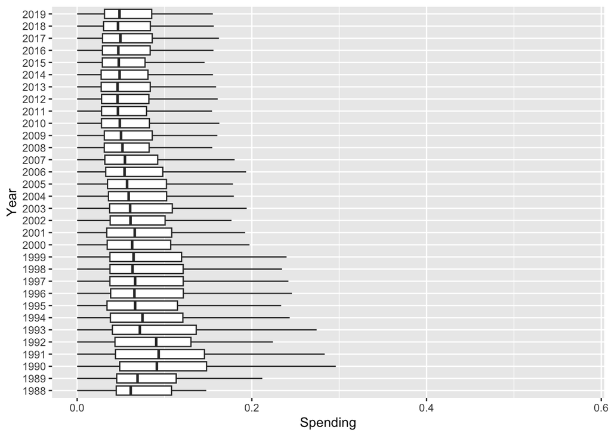

```r
ggplot(data = military_clean_longer, mapping = aes(x = Spending, y = Year)) +
  geom_boxplot(outlier.shape = NA)
```

```r
military_clean_longer|>
  group_by(Year,Country)|>
  slice_max(Spending)
```

```
# A tibble: 4,034 × 5
# Groups:   Year, Country [4,034]
   Country      Notes `Reporting year` Year  Spending
   <chr>        <chr> <chr>            <chr>    <dbl>
 1 Australia    <NA>  <NA>             1988    0.0704
 2 Austria      <NA>  <NA>             1988    0.0270
 3 Bangladesh   54    July-June        1988    0.103
 4 Belgium      <NA>  <NA>             1988    0.0464
 5 Bolivia      37    <NA>             1988    0.0843
 6 Botswana     <NA>  April-March      1988    0.100
 7 Brunei       57    <NA>             1988    0.132
 8 Burkina Faso †     <NA>             1988    0.139
 9 Canada       <NA>  <NA>             1988    0.0434
10 Colombia     39    <NA>             1988    0.109
# … with 4,024 more rows
```

```r
#military_clean_longer|>
  #filter(Year == "1990")
 # summarize(Spending = n())


#ggplot(data = military_clean_longer, mapping = aes(x = Spending, y = Country)) +
  #geom_boxplot(outlier.shape = NA)
```

## Part Two Answer

What year was the second largest military expenditure? What country had this expenditure?

**Bonus**: What is the reason for this large expenditure?